# Report Part 1

### Question 1

To approach this, we have a tsv file, first column and row are the names, so we must account for that using header and row.names. The tsv is read and assigned to a variable for easy usage.

```r
URL="https://raw.githubusercontent.com/ghazkha/Assessment4/refs/heads/main/gene_expression.tsv"
gene_expression_raw <- read.table(URL,stringsAsFactors = FALSE, header=TRUE, row.names=1)  #Reading the URL and formatting it correctly
head(gene_expression_raw) #Show the first 6 genes in the tbale
```

```
##                               GTEX.1117F.0226.SM.5GZZ7 GTEX.1117F.0426.SM.5EGHI
## ENSG00000223972.5_DDX11L1                            0                        0
## ENSG00000227232.5_WASH7P                           187                      109
## ENSG00000278267.1_MIR6859-1                          0                        0
## ENSG00000243485.5_MIR1302-2HG                        1                        0
## ENSG00000237613.2_FAM138A                            0                        0
## ENSG00000268020.3_OR4G4P                             0                        1
##                               GTEX.1117F.0526.SM.5EGHJ
## ENSG00000223972.5_DDX11L1                            0
## ENSG00000227232.5_WASH7P                           143
## ENSG00000278267.1_MIR6859-1                          1
## ENSG00000243485.5_MIR1302-2HG                        0
## ENSG00000237613.2_FAM138A                            0
## ENSG00000268020.3_OR4G4P                             0
```

### Question 2

To approach this, we create a new column called “Mean_Expression” in “gene_expression” and assign the mean values to this column.

```r
gene_expression <- gene_expression_raw #Create a new data set to modify, leave the original
gene_expression$Mean_Expression <- rowMeans(gene_expression_raw, na.rm = TRUE) #Finding the means of the rows, remove the empty values
head(gene_expression)
```

```
##                               GTEX.1117F.0226.SM.5GZZ7 GTEX.1117F.0426.SM.5EGHI
## ENSG00000223972.5_DDX11L1                            0                        0
## ENSG00000227232.5_WASH7P                           187                      109
## ENSG00000278267.1_MIR6859-1                          0                        0
## ENSG00000243485.5_MIR1302-2HG                        1                        0
## ENSG00000237613.2_FAM138A                            0                        0
## ENSG00000268020.3_OR4G4P                             0                        1
##                               GTEX.1117F.0526.SM.5EGHJ Mean_Expression
## ENSG00000223972.5_DDX11L1                            0       0.0000000
## ENSG00000227232.5_WASH7P                           143     146.3333333
## ENSG00000278267.1_MIR6859-1                          1       0.3333333
## ENSG00000243485.5_MIR1302-2HG                        0       0.3333333
## ENSG00000237613.2_FAM138A                            0       0.0000000
## ENSG00000268020.3_OR4G4P                             0       0.3333333
```

### Question 3

To approach this, we used the order function, and use - prefix to indicate decreasing order of Mean_Expression, then took the first 10 using head. The 10 genes are summarised in the table below:

```r
sorted_gene_expression <- gene_expression[order(-gene_expression$Mean_Expression), ] #Using the order function, sort the Mean expression in decreasing order
head(sorted_gene_expression, 10) #Show the first 10
```

```
##                           GTEX.1117F.0226.SM.5GZZ7 GTEX.1117F.0426.SM.5EGHI
## ENSG00000198804.2_MT-CO1                    267250                  1101779
## ENSG00000198886.2_MT-ND4                    273188                   991891
## ENSG00000198938.2_MT-CO3                    250277                  1041376
## ENSG00000198888.2_MT-ND1                    243853                   772966
## ENSG00000198899.2_MT-ATP6                   141374                   696715
## ENSG00000198727.2_MT-CYB                    127194                   638209
## ENSG00000198763.3_MT-ND2                    159303                   543786
## ENSG00000211445.11_GPX3                     464959                    39396
## ENSG00000198712.1_MT-CO2                    128858                   545360
## ENSG00000156508.17_EEF1A1                   317642                    39573
##                           GTEX.1117F.0526.SM.5EGHJ Mean_Expression
## ENSG00000198804.2_MT-CO1                    218923        529317.3
## ENSG00000198886.2_MT-ND4                    277628        514235.7
## ENSG00000198938.2_MT-CO3                    223178        504943.7
## ENSG00000198888.2_MT-ND1                    194032        403617.0
## ENSG00000198899.2_MT-ATP6                   151166        329751.7
## ENSG00000198727.2_MT-CYB                    141359        302254.0
## ENSG00000198763.3_MT-ND2                    149564        284217.7
## ENSG00000211445.11_GPX3                     306070        270141.7
## ENSG00000198712.1_MT-CO2                    122816        265678.0
## ENSG00000156508.17_EEF1A1                   339347        232187.3
```

### Question 4

We first filtered genes with a mean expression less than 10, then summed the number of TRUE values.

```r
sum(sorted_gene_expression$Mean_Expression <10) #Use sum function which counts the number of TRUE expressions, each row with Mean_Expression less than 10 will be TRUE
```

```
## [1] 35988
```

We found that A total of 35,988 genes have a mean expression less than 10. ### Question 5

We used hist to plot the frequency of mean expression values. Due to magnitude differences, we applied a log transformation (log(mean expression + 1)) to better visualize trends.

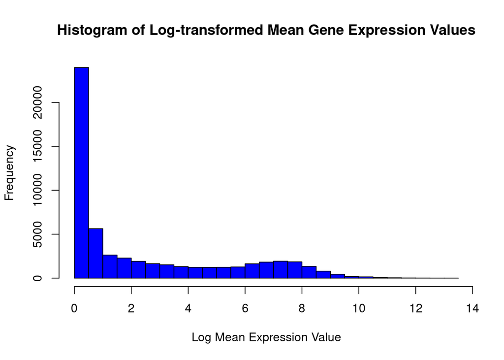

```r
# Log transformation of Mean values, avoiding log(0) issues
log_means <- log(gene_expression$Mean_Expression + 1)
# Create a histogram of the log-transformed Mean values
hist(log_means,
     main = "Histogram of Log-transformed Mean Gene Expression Values",
     xlab = "Log Mean Expression Value",
     ylab = "Frequency",
     col = "blue",
     border = "black",
     breaks = 30)
```

## Tree Growth Data

### Question 6

We imported the file using read.csv and assigned it to the variable “growth_data_raw”. The column names are: “Site”, “TreeID”, “Circumf_2005_cm”, “Circumf_2010_cm”, “Circumf_2015_cm”, and “Circumf_2020_cm”.

```r
URL="https://raw.githubusercontent.com/ghazkha/Assessment4/refs/heads/main/growth_data.csv"
growth_data_raw <- read.csv(URL)
colnames(growth_data_raw)
```

```
## [1] "Site"            "TreeID"          "Circumf_2005_cm" "Circumf_2010_cm"
## [5] "Circumf_2015_cm" "Circumf_2020_cm"
```

### Question 7

```r
northeast_data <- growth_data_raw[growth_data_raw$Site == "northeast", ] #Subsetting all the northeast data
southwest_data <- growth_data_raw[growth_data_raw$Site == "southwest", ] #Subsetting all the southwest data

northeast_data_task7 <- northeast_data[, c("Circumf_2005_cm", "Circumf_2020_cm")] #Subsetting the start (2005) and end (2020) for northeast
southwest_data_task7 <- southwest_data[, c("Circumf_2005_cm", "Circumf_2020_cm")] #Subsetting the start (2005) and end (2020) for southwest

northeast_results_task7 <- data.frame(
  Site = "northeast",  # Keep the site name in the first column
  mean_circumf_2005 = mean(northeast_data_task7$Circumf_2005_cm, na.rm = TRUE),
  sd_circumf_2005 = sd(northeast_data_task7$Circumf_2005_cm,na.rm=TRUE),
  mean_circumf_2020 = mean(northeast_data_task7$Circumf_2020_cm, na.rm = TRUE),
  sd_circumf_2020 = sd(northeast_data_task7$Circumf_2020_cm,na.rm=TRUE),
  stringsAsFactors = FALSE # Avoid converting strings to factors
)


southwest_results_task7 <- data.frame(
  Site = "southwest",  # Keep the site name in the first column
  mean_circumf_2005 = mean(southwest_data_task7$Circumf_2005_cm, na.rm = TRUE),
  sd_circumf_2005 = sd(southwest_data_task7$Circumf_2005_cm,na.rm=TRUE),
  mean_circumf_2020 = mean(southwest_data_task7$Circumf_2020_cm, na.rm = TRUE),
  sd_circumf_2020 = sd(southwest_data_task7$Circumf_2020_cm,na.rm=TRUE),
  stringsAsFactors = FALSE # Avoid converting strings to factors
)

northeast_results_task7
```

```
##        Site mean_circumf_2005 sd_circumf_2005 mean_circumf_2020 sd_circumf_2020
## 1 northeast             5.292       0.9140267            54.228        25.22795
```

```r
southwest_results_task7
```

```
##        Site mean_circumf_2005 sd_circumf_2005 mean_circumf_2020 sd_circumf_2020
## 1 southwest             4.862        1.147471            45.596        17.87345
```

### Question 8

We extended the previous data by adding a site identifier for merging, then merged it into “combined_data_task8” for plotting. Separate boxplots were made for each year due to large magnitude differences, which would obscure data variation.

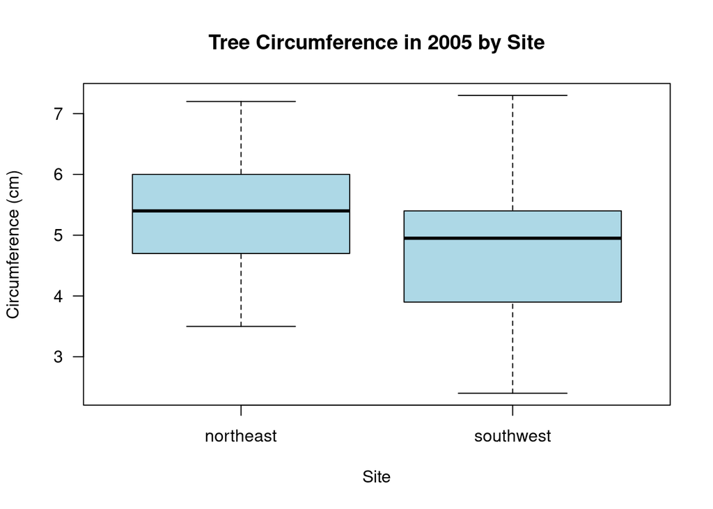

```r
# Create data for northeast site
northeast_task_8 <- data.frame(
  Circumference = c(northeast_data_task7$Circumf_2005_cm, northeast_data_task7$Circumf_2020_cm),
  Year = rep(c("2005", "2020"), each = nrow(northeast_data)),
  Site = "northeast"
)

# Create data for southwest site
southwest_task_8 <- data.frame(
  Circumference = c(southwest_data$Circumf_2005_cm, southwest_data$Circumf_2020_cm),
  Year = rep(c("2005", "2020"), each = nrow(southwest_data)),
  Site = "southwest"
)

# Combine the data into a single data frame for plotting purposes
combined_data_task8 <- rbind(northeast_task_8, southwest_task_8)

# Create a separate plot for 2005
boxplot(Circumference ~ Site,
        data = combined_data_task8[combined_data_task8$Year == "2005", ],
        main = "Tree Circumference in 2005 by Site",
        xlab = "Site",
        ylab = "Circumference (cm)",
        col = "lightblue",
        las = 1)
```

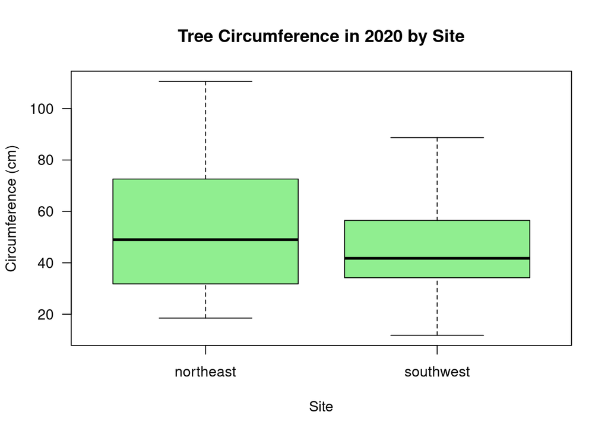

```r
# Create a separate plot for 2020
boxplot(Circumference ~ Site,
        data = combined_data_task8[combined_data_task8$Year == "2020", ],
        main = "Tree Circumference in 2020 by Site",
        xlab = "Site",
        ylab = "Circumference (cm)",
        col = "lightgreen",
        las = 1)
```

### Question 9

We subsetted the data for northeast and southwest, focusing on 2010 and 2020 to analyze growth over the last 10 years. After calculating the mean for each year, we computed the mean growth by subtracting the 2010 mean from 2020.

```r
northeast_data_task9 <- northeast_data[, c("Circumf_2010_cm", "Circumf_2020_cm")] # Subset the 2010 and 2020 data for northeast
southwest_data_task9 <- southwest_data[, c("Circumf_2010_cm", "Circumf_2020_cm")]# Subset the 2010 and 2020 data for southwest

northeast_results_task9 <- data.frame(
  Site = "northeast",  # Keep the site name in the first column
  mean_circumf_2010 = mean(northeast_data_task9$Circumf_2010_cm, na.rm = TRUE),
  sd_circumf_2010 = sd(northeast_data_task9$Circumf_2010_cm,na.rm=TRUE),
  mean_circumf_2020 = mean(northeast_data_task9$Circumf_2020_cm, na.rm = TRUE),
  sd_circumf_2020 = sd(northeast_data_task9$Circumf_2020_cm,na.rm=TRUE),
  stringsAsFactors = FALSE # Don't make strings as factors, because we have site name
)

southwest_results_task9 <- data.frame(
  Site = "southwest",  # Keep the site name in the first column
  mean_circumf_2010 = mean(southwest_data_task9$Circumf_2010_cm, na.rm = TRUE),
  sd_circumf_2010 = sd(southwest_data_task9$Circumf_2010_cm,na.rm=TRUE),
  mean_circumf_2020 = mean(southwest_data_task9$Circumf_2020_cm, na.rm = TRUE),
  sd_circumf_2020 = sd(southwest_data_task9$Circumf_2020_cm,na.rm=TRUE),
  stringsAsFactors = FALSE # Don't make strings as factors, because we have site name
)

Mean_Growth_northeast_10y <- northeast_results_task9$mean_circumf_2020 - northeast_results_task9$mean_circumf_2010 # Subtraction of 2020 and 2010 mean data
Mean_Growth_southwest_10y <- southwest_results_task9$mean_circumf_2020 - southwest_results_task9$mean_circumf_2010 # Subtraction of 2020 and 2010 mean data

# Display the results
Mean_Growth_northeast_10y
```

```
## [1] 42.94
```

```r
Mean_Growth_southwest_10y
```

```
## [1] 35.49
```

The mean growth at the northeast site over the last 10 years was: 42.94 cm, while it was 35.49cm for southwest.

### Question 10

For the t-test, we checked the variance using sd, finding it unequal. Thus, a Welch t-test was applied, yielding p = 0.06229, which is not statistically significant (p > 0.05). There was no significant difference in 10-year growth between the sites.

```r
# Create the data set for this task, done via subtracting the 2020 data from the 2010 data for growth over 10 years
northeast_data_task10 <- data.frame(
  Growth_10yr = northeast_data_task9$Circumf_2020_cm - northeast_data_task9$Circumf_2010_cm)

southwest_data_task10 <- data.frame(
  Growth_10yr = southwest_data_task9$Circumf_2020_cm - southwest_data_task9$Circumf_2010_cm)

# Check if sd is the same, if they are not, then variances are not the same for t-test
sd(northeast_data_task10$Growth_10yr)
```

```
## [1] 22.8151
```

```r
sd(southwest_data_task10$Growth_10yr)
```

```
## [1] 16.05704
```

```r
# Assign t.test to a variable and print the results
t_test_result <- t.test(northeast_data_task10$Growth_10yr, southwest_data_task10$Growth_10yr)
print(t_test_result)
```

```
##
##  Welch Two Sample t-test
##
## data:  northeast_data_task10$Growth_10yr and southwest_data_task10$Growth_10yr
## t = 1.8882, df = 87.978, p-value = 0.06229
## alternative hypothesis: true difference in means is not equal to 0
## 95 percent confidence interval:
##  -0.3909251 15.2909251
## sample estimates:
## mean of x mean of y
##     42.94     35.49
```